# Seattle Police Use of Force Analysis

## Problem

The Black Lives Matter movement has highlighted the disporoportionate use of force by police officers on the Black community. Public data from the Seattle Police Department (SPD) was used to explore the policing of communities of color.

## Conclusions

- **Black residents are more likely to be involved in SPD use of force incidents**
  - Looking at the number of use of force incidents by race, there are an abnormally high number of incidents involving Black civilians.
  - Incidents also seem high for American Indian, Alaska Native, Native Hawaiian and Pacific Islander populations, but due to low population numbers this is less definitive.
  - White civilians were involved in slightly fewer UoF incidents than expected.
  - Perhaps surprisingly, Hispanic, Latinx and Asian civilians had the fewest incidents recorded.
  - Over 18% of incidents had no race reported for the civilian, which could greatly impact this analyis.

[figure not shown]

- **Certain officers are much more likely to use force**
  - Most officers have very few use of force incidents reported (blue density in the left bottom corner).
  - The officers with many use of force incidents and those that have a higher ratio of serious incidents to less serious ones (above the trendline) seem to be disproportionately involved in Officer Involved Shootings (red X).
  - This data does not tell us about officers that never generate UoF incidents, how long officers are on the force, how many arrests officers make without generating use of force reports, or if the officers involved in more use of force incidents have roles -- like being part of the SWAT team -- that would explain their high levels of forceful interactions.

[figure not shown]

- **Some precints seem better at de-escalation**
  - Looking at precinct level trends, the Southwest Precinct stands out for having low levels of use of force incidents, incidents per officer, officer involved shootings, and low ratio of more serious use of force to less serious perhaps suggesting a culture of de-escalation.

[figure not shown]

- **Use of force incidents tend to happen in areas with elevated crime rates**
  - There is a very strong spatial correlation between rates of interpersonal crimes and "crimes against society" and use of force incidents.
  - The correlation with property crime is very weak, perhaps because fewer arrests are made in these types of crimes, or when the arrest is made it happens away from the neighborhood of the property crime.
  - Data on actual arrest and ticketing locations was not available, and would help clarify if use of force is applied evenly as a percentage of police encounters in each neighborhood.

[figure not shown]

- **Use of force incidents track the overall crime rate over time**
  - Reporting on use of force began under a consent decree with the Department of Justice in 2014. Incidents of UoF trended down until the beginning of 2017, rose through 2017 and 2018, then fell dramatically in the beginning of 2019, staying low since.
  - The timing of these changes may be related to federal enforcement of the consent decree, but this also generally tracks the overall crime rate for the city, so may just reflect the number of police-civilian arrests and interractions.
  - Because force reports are filed by the police themselves, poor reporting and better policing would have identical impacts on the data.

[figure not shown]

## Links to the data:

- [SPD Use of Force reports](https://data.seattle.gov/Public-Safety/Use-Of-Force/ppi5-g2bj)
- Police beat boundary maps for [pre-2015](https://opendata.arcgis.com/datasets/ef08a89e6ec94c7a82515e47384f2808_0.geojson), [2015-17](https://opendata.arcgis.com/datasets/45495a3ab3a141dcb3277dc91c52ec5f_1.geojson), and [2018-20](https://opendata.arcgis.com/datasets/36378b7acb8a464c8019b9618fecd0dd_2.geojson)
- [Police crime reports](https://data.seattle.gov/Public-Safety/SPD-Crime-Data-2008-Present/tazs-3rd5)
- Demographic details from the American Community Survey (Census Bureau)

## Complete code

##### Add modules for geospatial analysis and census data acquisition

```python
import sys
# !conda install -c conda-forge --yes --prefix {sys.prefix} geopandas
# !conda install -c conda-forge --yes --prefix {sys.prefix} descartes
# !{sys.executable} -m pip install censusdata
```

```python
# Load necessary libraries

# data aquisition
import censusdata

# data handling and mathematical manipulation
import pandas as pd
from pandas.api.types import CategoricalDtype
import numpy as np
import geopandas as gpd
from datetime import date, timedelta
import descartes
from random import choice
from scipy.stats import linregress

# statsmodeling
import statsmodels.graphics.tsaplots as splt
import statsmodels.api as statsmodels
import statsmodels.formula.api as sm
import statsmodels.tsa.seasonal as sts
import statsmodels.tsa.arima_process as arima_process
from statsmodels.tsa.stattools import adfuller
from statsmodels.tsa.arima_model import ARIMA
import six
import sys
sys.modules['sklearn.externals.six'] = six
import joblib
sys.modules['sklearn.externals.joblib'] = joblib
from pmdarima import auto_arima
from sklearn.metrics import mean_squared_error


#Plotting
import matplotlib.pyplot as plt
import seaborn as sns
import matplotlib as mpl
%matplotlib inline

# viewing output settings
sns.set(rc = {'figure.figsize': (12, 12)})
pd.set_option('display.max_columns', None)
import warnings
warnings.simplefilter('ignore', category=DeprecationWarning)
warnings.filterwarnings("ignore")
```

### Load SPD Use of Force data set

```python
# load use of force data set
spd_uof = pd.read_csv('data/Use_Of_Force.csv',
                      parse_dates = ['Occured_date_time'],
                      dtype = {'Incident_Num' : 'category',
                               'Officer_ID' : 'category',
                               'Subject_ID' : 'category'})
spd_uof.head(3)
```

|  | ID | Incident_Num | Incident_Type | Occured_date_time | Precinct | Sector | Beat | Officer_ID | Subject_ID | Subject_Race | Subject_Gender |
| --- | --- | --- | --- | --- | --- | --- | --- | --- | --- | --- | --- |
| 0 | 2014UOF-0001-1377-203 | 251 | Level 1 - Use of Force | 2014-06-07 00:09:00 | East | CHARLIE | C2 | 1594 | 203 | Black or African American | Male |
| 1 | 2014UOF-0002-1098-166 | 218 | Level 1 - Use of Force | 2014-05-30 14:06:00 | East | GEORGE | G1 | 1673 | 166 | White | Male |
| 2 | 2014UOF-0003-1031-125 | 178 | Level 1 - Use of Force | 2014-05-23 17:24:00 | West | KING | K3 | 1690 | 125 | Asian | Female |

### Collect demographic information about Seattle using the American Community Survey

```python
# Gather census information per api.census.gov/data/2015/acs/acs5/variables.html
decoder = {'B01002_001E' : 'median_age',
           'B01001_001E' : 'total_age',
           'B01001_003E' : 'male_under_5',
           'B01001_004E' : 'male_5_9',
           'B01001_005E' : 'male_10_14',
           'B01001_006E' : 'male_15_17',
           'B01001_007E' : 'male_18_19',
           'B01001_008E' : 'male_20',
           'B01001_009E' : 'male_21',
           'B01001_010E' : 'male_22_24',
           'B01001_020E' : 'male_65_66',
           'B01001_021E' : 'male_67_69',
           'B01001_022E' : 'male_70_74',
           'B01001_023E' : 'male_75_79',
           'B01001_024E' : 'male_80_84',
           'B01001_025E' : 'male_85_over',
           'B01001_027E' : 'female_under_5',
           'B01001_028E' : 'female_5_9',
           'B01001_029E' : 'female_10_14',
           'B01001_030E' : 'female_15_17',
           'B01001_031E' : 'female_18_19',
           'B01001_032E' : 'female_20',
           'B01001_033E' : 'female_21',
           'B01001_034E' : 'female_22_24',
           'B01001_044E' : 'female_65_66',
           'B01001_045E' : 'female_67_69',
           'B01001_046E' : 'female_70_74',
           'B01001_047E' : 'female_75_79',
           'B01001_048E' : 'female_80_84',
           'B01001_049E' : 'female_85_over',
           'B19013_001E' : 'median_household_income',
           'C17002_001E' : 'income_to_poverty_total_count',
           'C17002_002E' : 'income_to_poverty_lt_point_5',
           'C17002_003E' : 'income_to_poverty_point_5_to_1',
           'C17002_004E' : 'income_to_poverty_1_to_1_point_24',
           'C17002_005E' : 'income_to_poverty_1_point_24_to_1_point_49',
           'B03002_001E' : 'count_all_races',
           'B03002_003E' : 'count_white',
           'B03002_004E' : 'count_black',
           'B03002_005E' : 'count_ai_na',
           'B03002_006E' : 'count_asian',
           'B03002_007E' : 'count_hawaiian_pi',
           'B03002_012E' : 'count_latinx',
           'B07013_001E' : 'all_residence',
           'B07013_002E' : 'owner_occupied_residence'}
```

```python
#accumulator df
census_tract_demo = pd.DataFrame()

# just get King county demographics
fips = ['53033']

for fip in fips:
    county_tract = censusdata.download('acs5', 2018, censusdata.censusgeo([('state', fip[:2]), ('county', fip[2:]), ('tract', '*')]),
                                    ['B01002_001E', 'B19013_001E', 'B01001_001E', 'B01001_003E', 'B01001_004E', 'B01001_005E',
                                     'B01001_006E', 'B01001_007E', 'B01001_008E', 'B01001_009E', 'B01001_010E', 'B01001_020E',
                                     'B01001_021E', 'B01001_022E', 'B01001_023E', 'B01001_024E', 'B01001_025E', 'B01001_027E',
                                     'B01001_028E', 'B01001_029E', 'B01001_030E', 'B01001_031E', 'B01001_032E', 'B01001_033E',
                                     'B01001_034E', 'B01001_044E', 'B01001_045E', 'B01001_046E', 'B01001_047E', 'B01001_048E',
                                     'B01001_049E', 'C17002_001E', 'C17002_002E', 'C17002_003E', 'C17002_004E', 'C17002_005E',
                                     'B03002_001E', 'B03002_003E', 'B03002_004E', 'B03002_005E', 'B03002_006E', 'B03002_007E',
                                     'B03002_012E', 'B07013_001E', 'B07013_002E',
                                    ])
    county_tract = county_tract.reset_index()
    county_tract = county_tract.rename(columns=decoder)

    # loop through tracts to create aggregate statistics
    iter_ = county_tract.copy()
    for row in iter_.itertuples():
        # get geocode for merging with map
        geocode = fip + str(row.index)[-6:]
        county_tract.loc[row.Index, 'geocode'] = geocode

        # get income level information
        try:
            low_income_pct = (row.income_to_poverty_lt_point_5 + \
                         row.income_to_poverty_point_5_to_1 + \
                         row.income_to_poverty_1_to_1_point_24 + \
                         row.income_to_poverty_1_point_24_to_1_point_49) / \
                         row.income_to_poverty_total_count
        except:
            low_income_pct = np.nan
        county_tract.loc[row.Index, 'low_income_pct'] = low_income_pct

        # get racial composition of area
        try:
            pct_white = row.count_white / row.count_all_races
            pct_black = row.count_black / row.count_all_races
            pct_latinx = row.count_latinx / row.count_all_races
            pct_ai_na = row.count_ai_na / row.count_all_races
            pct_asian = row.count_asian / row.count_all_races
            pct_hawaiian_pi = row.count_hawaiian_pi / row.count_all_races
        except:
            pct_white, pct_black, pct_latinx, pct_ai_na, pct_asian = np.nan, np.nan, np.nan, np.nan, np.nan

        county_tract.loc[row.Index, 'pct_white'] = pct_white
        county_tract.loc[row.Index, 'pct_black'] = pct_black
        county_tract.loc[row.Index, 'pct_latinx'] = pct_latinx
        county_tract.loc[row.Index, 'pct_ai_na'] = pct_ai_na
        county_tract.loc[row.Index, 'pct_asian'] = pct_asian
        county_tract.loc[row.Index, 'pct_hawaiian_pi'] = pct_hawaiian_pi

        # get home ownership
        try:
            pct_homeowner = row.owner_occupied_residence / row.all_residence
        except:
            pct_homeowner = np.nan
        county_tract.loc[row.Index, 'pct_homeowner'] = pct_homeowner

        # get age breakdown
        try:
            pct_child = (row.male_under_5 + row.male_5_9 + row.male_10_14 + row.male_15_17 \
                        + row.female_under_5 + row.female_5_9 + row.female_10_14 \
                        + row.female_15_17) / row.total_age
            pct_uni = (row.male_18_19 + row.male_20 + row.male_21 + row.male_22_24 \
                      + row.female_18_19 + row.female_20 + row.female_21 \
                      + row.female_22_24) / row.total_age
            pct_senior = (row.male_65_66 + row.male_67_69 + row.male_70_74 + row.male_75_79 \
                         + row.male_80_84 + row.male_85_over + row.female_65_66 + row.female_67_69 \
                         + row.female_70_74 + row.female_75_79 + row.female_80_84 \
                         + row.female_85_over) / row.total_age
        except:
            pct_child, pct_uni, pct_senior = np.nan, np.nan, np.nan
        county_tract.loc[row.Index, 'pct_child'] = pct_child
        county_tract.loc[row.Index, 'pct_uni'] = pct_uni
        county_tract.loc[row.Index, 'pct_senior'] = pct_senior

        # estimate size of census tract population
        county_tract.loc[row.Index, 'pop_estimate'] = max([row.all_residence, row.count_all_races, \
                                    row.income_to_poverty_total_count, row.total_age])

    # keep aggregates stats
    keep_cols = ['geocode', 'pop_estimate', 'median_age', 'pct_child', 'pct_uni', 'pct_senior',
                 'median_household_income', 'low_income_pct', 'pct_homeowner', 'pct_white',
                 'pct_black', 'pct_latinx', 'pct_asian', 'pct_ai_na', 'pct_hawaiian_pi',
                 'count_white', 'count_black', 'count_latinx', 'count_ai_na', 'count_asian',
                 'count_hawaiian_pi']

    # append aggregate data to accumulator
    census_tract_demo = pd.concat([census_tract_demo, county_tract[keep_cols]], axis = 0)


# name the columns for the accumulator dataframe
census_tract_demo.columns = keep_cols

census_tract_demo.head()
```

|  | geocode | pop_estimate | median_age | pct_child | pct_uni | pct_senior | median_household_income | low_income_pct | pct_homeowner | pct_white | pct_black | pct_latinx | pct_asian | pct_ai_na | pct_hawaiian_pi | count_white | count_black | count_latinx | count_ai_na | count_asian | count_hawaiian_pi |
| --- | --- | --- | --- | --- | --- | --- | --- | --- | --- | --- | --- | --- | --- | --- | --- | --- | --- | --- | --- | --- | --- |
| 0 | 53033025701 | 6215.0 | 32.8 | 0.171842 | 0.082703 | 0.112148 | 62953 | 0.167337 | 0.318980 | 0.506838 | 0.138536 | 0.072727 | 0.173290 | 0.017377 | 0.027675 | 3150 | 861 | 452 | 108 | 1077 | 172 |
| 1 | 53033026500 | 4392.0 | 34.7 | 0.274590 | 0.066485 | 0.122268 | 39301 | 0.440230 | 0.293819 | 0.296448 | 0.203324 | 0.193306 | 0.192623 | 0.000000 | 0.024362 | 1302 | 893 | 849 | 0 | 846 | 107 |
| 2 | 53033027000 | 3147.0 | 40.7 | 0.180807 | 0.080712 | 0.115348 | 54844 | 0.179536 | 0.625687 | 0.500159 | 0.049889 | 0.245313 | 0.156975 | 0.020337 | 0.012393 | 1574 | 157 | 772 | 64 | 494 | 39 |
| 3 | 53033027701 | 5008.0 | 51.4 | 0.192292 | 0.039337 | 0.239018 | 71444 | 0.121838 | 0.758691 | 0.890375 | 0.000399 | 0.083866 | 0.013379 | 0.000000 | 0.000000 | 4459 | 2 | 420 | 0 | 67 | 0 |
| 4 | 53033028200 | 4929.0 | 32.7 | 0.225401 | 0.106310 | 0.102455 | 57267 | 0.362548 | 0.289831 | 0.322986 | 0.248529 | 0.177318 | 0.144654 | 0.000000 | 0.019071 | 1592 | 1225 | 874 | 0 | 713 | 94 |

```python
groups = ['count_ai_na', 'count_asian',  'count_black', 'count_latinx',
                 'count_hawaiian_pi', 'count_white',]

spd_cats = ['American Indian/Alaska Native', 'Asian', 'Black or African American',
       'Hispanic or Latino', 'Nat Hawaiian/Oth Pac Islander', 'White']

spd_pct = []

for col in groups:
    pct = census_tract_demo[col].sum() / census_tract_demo['pop_estimate'].sum()
    spd_pct.append(pct)

seattle_race_pct = pd.DataFrame(zip(spd_cats, spd_pct),
                               columns = ['race', 'pop_pct']).set_index('race')
seattle_race_pct
```

| race | pop_pct |
| --- | --- |
| American Indian/Alaska Native | 0.005186 |
| Asian | 0.170482 |
| Black or African American | 0.061377 |
| Hispanic or Latino | 0.095567 |
| Nat Hawaiian/Oth Pac Islander | 0.007561 |
| White | 0.604418 |

```python
# adjust race percentages to 100%
seattle_race_pct['pop_pct'] = seattle_race_pct['pop_pct'] / seattle_race_pct['pop_pct'].sum()
```

```python
# merge UoF by race with Seattle population percentages
UoF_by_race = spd_uof.groupby(['Subject_Race', 'Incident_Type']).agg(
    Incident_Count = ('Incident_Num', 'nunique')
).unstack(fill_value=0)

# clean up column names
UoF_by_race.columns = levels = ['Incident_Count_Level_1',
                       'Incident_Count_Level_2',
                       'Incident_Count_Level_3_OIS',
                       'Incident_Count_Level_3']

# merge use of force stats with population percentages
UoF_by_race_by_pop = UoF_by_race.join(seattle_race_pct, how='left')

pct_not_spec = UoF_by_race_by_pop.loc['Not Specified', levels].sum(axis=0) / UoF_by_race_by_pop[levels].sum().sum()
print(f'The race of the civilian was not recorded in {pct_not_spec*100:.1f}% of Use of Force incidents.')

UoF_by_race_by_pop
```

```
The race of the civilian was not recorded in 18.1% of Use of Force incidents.
```

| Subject_Race | Incident_Count_Level_1 | Incident_Count_Level_2 | Incident_Count_Level_3_OIS | Incident_Count_Level_3 | pop_pct |
| --- | --- | --- | --- | --- | --- |
| American Indian/Alaska Native | 76 | 29 | 0 | 4 | 0.005490 |
| Asian | 310 | 81 | 7 | 5 | 0.180482 |
| Black or African American | 2651 | 800 | 18 | 31 | 0.064978 |
| Hispanic or Latino | 338 | 76 | 0 | 2 | 0.101172 |
| Nat Hawaiian/Oth Pac Islander | 46 | 18 | 1 | 2 | 0.008005 |
| Not Specified | 1513 | 436 | 7 | 21 | NaN |
| White | 3345 | 1046 | 35 | 42 | 0.639873 |

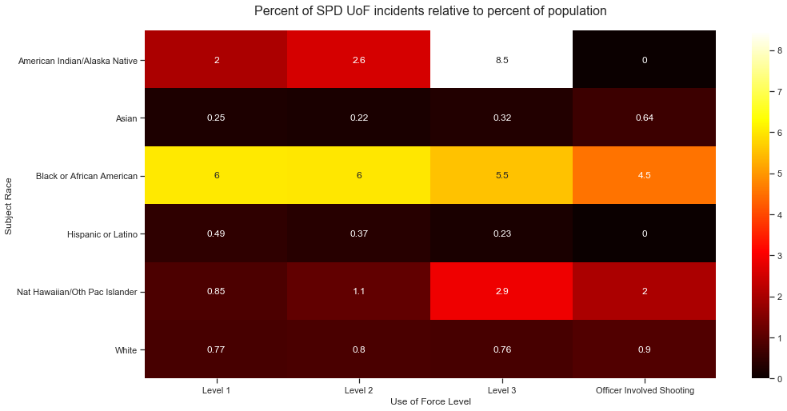

```python
# drop Not Specifed stas from analysis
UoF_by_race_by_pop.dropna(inplace=True)

# Calculate how many uses of force would be expected for each racial group
# if incidents happened to every group equally
level_1_sum = UoF_by_race_by_pop['Incident_Count_Level_1'].sum()
UoF_by_race_by_pop.loc[:, 'Level_1_expected'] = UoF_by_race_by_pop['pop_pct'] * level_1_sum

level_2_sum = UoF_by_race_by_pop['Incident_Count_Level_2'].sum()
UoF_by_race_by_pop.loc[:, 'Level_2_expected'] = UoF_by_race_by_pop['pop_pct'] * level_2_sum

level_3_sum = UoF_by_race_by_pop['Incident_Count_Level_3'].sum()
UoF_by_race_by_pop.loc[:, 'Level_3_expected'] = UoF_by_race_by_pop['pop_pct'] * level_3_sum

level_3_OIS_sum = UoF_by_race_by_pop['Incident_Count_Level_3_OIS'].sum()
UoF_by_race_by_pop.loc[:, 'Level_3_OIS_expected'] = UoF_by_race_by_pop['pop_pct'] * level_3_OIS_sum

UoF_by_race_by_pop.loc[:, 'Level_1_pct_of_expected'] = UoF_by_race_by_pop['Incident_Count_Level_1'] \
                                                           / UoF_by_race_by_pop['Level_1_expected']
UoF_by_race_by_pop.loc[:, 'Level_2_pct_of_expected'] = UoF_by_race_by_pop['Incident_Count_Level_2'] \
                                                           / UoF_by_race_by_pop['Level_2_expected']
UoF_by_race_by_pop.loc[:, 'Level_3_pct_of_expected'] = UoF_by_race_by_pop['Incident_Count_Level_3'] \
                                                           / UoF_by_race_by_pop['Level_3_expected']
UoF_by_race_by_pop.loc[:, 'Level_3_OIS_pct_of_expected'] = UoF_by_race_by_pop['Incident_Count_Level_3_OIS'] \
                                                           / UoF_by_race_by_pop['Level_3_OIS_expected']

# list of columns to plot
pct_of_expected =  ['Level_1_pct_of_expected', 'Level_2_pct_of_expected',
                    'Level_3_pct_of_expected', 'Level_3_OIS_pct_of_expected']

# plot using heatmap
plt.figure(figsize = (16,8))
g = sns.heatmap(UoF_by_race_by_pop[pct_of_expected],
                cmap = 'hot',
                annot=True);
plt.title('Percent of SPD UoF incidents relative to percent of population',
          fontdict = {'fontsize': 16}, pad = 20);
plt.xticks(rotation=0, ticks = [0.5, 1.5, 2.5, 3.5], labels= ['Level 1', 'Level 2',
                    'Level 3', 'Officer Involved Shooting']);
g.set(xlabel = 'Use of Force Level',
      ylabel = 'Subject Race');
```

## Do certain officers or precincts create disproportionate number of Use of Force incidents

### Incidents by officer, plotted by incident seriousness, grouped by precinct

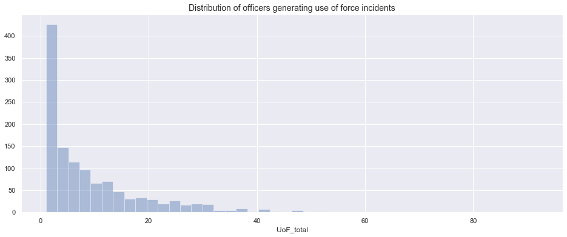

```python
# Use one hot encoding to get counts of incident types by officer
incidents = pd.get_dummies(spd_uof['Incident_Type'])
incidents = incidents.rename(columns={'Level 1 - Use of Force' : 'UoF_1'})
incidents.loc[:, 'UoF_2_and_3'] = incidents.sum(axis=1) - incidents.UoF_1
incidents
incidents_by_officer = pd.concat([spd_uof, incidents], axis=1)

# custom function to assign officers to precints based on where the majority
# of their incidents take place. Eliminates irregular values in the date like
# 'X' and if precints are tied makes the choice by random to avoid systemic bias
valid = ['West', 'North', 'East', 'South', 'Southwest']
def rand_valid(x):
    # options are modal values
    options = [y for y in pd.Series.mode(x) if y in valid]

    # if no valid precints, return NaN
    if len(options) == 0:
        return np.nan

    # if single valid mode, return that precinct
    elif len(options) == 1:
        return options[0]

    # if choice of two or more valid modal precincts, choose at random
    else:
        return choice(options)

# for each officer, count incidents of varying degrees of seriousness
force_incidents = incidents_by_officer.groupby(['Officer_ID']).agg(
    UoF_1 = ('UoF_1', 'sum'),
    UoF_2_and_3 = ('UoF_2_and_3', 'sum'),
    UoF_OIS = ('Level 3 - OIS', 'sum'),
    UoF_total = ('Incident_Type', 'count'),
    Precinct = ('Precinct', rand_valid),
)
plt.figure(figsize=(16,6));
sns.distplot(force_incidents['UoF_total'], kde=False);
plt.title('Distribution of officers generating use of force incidents',
          fontdict = {'fontsize' : 14});
```

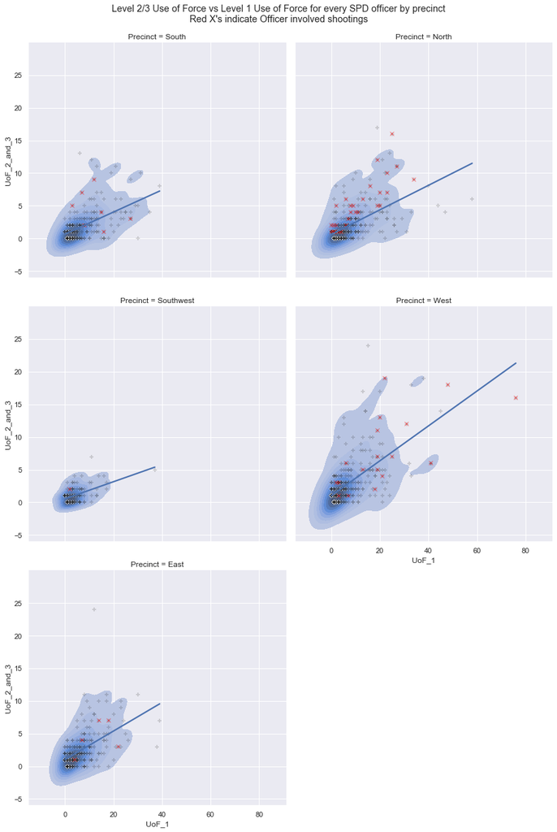

```python
# drop officers with no precinct assignment for plotting
force_incidents_no_na = force_incidents.dropna(axis=0).copy()

# assign a special marker for officers involved in shootings
marker_map = {x : "x" for x in list(force_incidents.UoF_OIS.value_counts().index)}
marker_map[0] = 'None'

# use FacetGrid to look at the ficve precincts in parallel
g = sns.FacetGrid(force_incidents_no_na,
                  col = 'Precinct',
                  col_wrap = 2,
                  height = 6)


# use 2D KDE plot to better visualize UoF distribution
g.map(sns.kdeplot, 'UoF_1', 'UoF_2_and_3', shade = True);

# use a regplot to see the relationship between mild and severe uses of force
g.map(sns.regplot, 'UoF_1', 'UoF_2_and_3', scatter = False, ci=None)

# use a scatter plot of black plus signs to visualize outlier cops
g.map(sns.scatterplot, 'UoF_1',
                       'UoF_2_and_3',
                       marker = 'P',
                       alpha = .15,
                       color = 'black',
     );

# add red X's for police involved in the highest levels of UoF,
# shooting at civilians
g.map(sns.scatterplot, 'UoF_1',
                       'UoF_2_and_3',
                       style = force_incidents_no_na['UoF_OIS'],
                       markers = marker_map,
                       alpha = 1,
                       color = 'red',
     );

plt.subplots_adjust(top=0.935);
g.fig.suptitle(f"Level 2/3 Use of Force vs Level 1 Use of Force for every SPD officer by precinct\nRed X's indicate Officer involved shootings");
```

### Incidents by precinct: total, per officer, and ratio of more serious (Level 2/3) to less serious (Level 1) incidents

```python
# look at incidents by precinct, counting number of incidents and number of officers involved in incidents
precinct_incidents_officers = spd_uof.groupby(['Precinct']).agg(
    incidents = ('Incident_Num', 'count'),
    officers = ('Officer_ID', 'nunique')
).reset_index()

# determine how many incidents are not assigned a valid precinct name
no_precinct = precinct_incidents_officers.loc[~(precinct_incidents_officers['Precinct'].isin(valid))]['incidents'].sum()
total_incidents = precinct_incidents_officers['incidents'].sum()
print(f'Of the total Use of Force incidents, {no_precinct/total_incidents*100:.1f}% are not attributed to a precinct')
```

```
Of the total Use of Force incidents, 5.9% are not attributed to a precinct
```

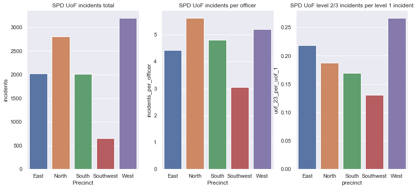

```python
# drop invalid precinct incidents to compare precints. Get incidents per officer
precinct_incidents_officers = precinct_incidents_officers.loc[precinct_incidents_officers['Precinct'].isin(valid)]
precinct_incidents_officers.loc[:, 'incidents_per_officer'] = precinct_incidents_officers['incidents'] / \
                                                              precinct_incidents_officers['officers']

# Find slope of the curves for each scatterplot above
precints = ['West', 'North', 'East', 'South', 'Southwest']

# make collector dataframe
uof_23_per_uof_1 = pd.DataFrame(columns = ['precinct', 'uof_23_per_uof_1'])

for precinct in precints:
    # get x,y coordinates of above plots
    X = force_incidents_no_na.loc[force_incidents_no_na['Precinct'] == precinct]['UoF_1']
    Y = force_incidents_no_na.loc[force_incidents_no_na['Precinct'] == precinct]['UoF_2_and_3']

    # get the slope of the best fit line, append to collector dataframe
    slope, a, b, c, d = linregress(x = X, y = Y)
    df= pd.DataFrame([[precinct, slope]], columns = ['precinct', 'uof_23_per_uof_1'])
    uof_23_per_uof_1 = uof_23_per_uof_1.append(df, ignore_index=True)

# sort precincts alphabetically for easier comparison across sub plots
uof_23_per_uof_1 = uof_23_per_uof_1.sort_values(by = 'precinct')

# plot total incidents by precinct
plt.figure(figsize = (14,6));
plt.subplot(1,3,1)
sns.barplot(data = precinct_incidents_officers,
            x = 'Precinct',
            y = 'incidents',
#             color = 'mediumblue',
            );
plt.title('SPD UoF incidents total',
          fontdict = {'fontsize': 12});

# plot incidents per officer by precinct
plt.subplot(1,3,2)
sns.barplot(data = precinct_incidents_officers,
            x = 'Precinct',
            y = 'incidents_per_officer',
#             color = 'mediumblue',
           );
plt.title('SPD UoF incidents per officer',
          fontdict = {'fontsize': 12});

# plot incidents per officer by precinct
plt.subplot(1,3,3)
sns.barplot(data = uof_23_per_uof_1,
            x = 'precinct',
            y = 'uof_23_per_uof_1',
#             color = 'mediumblue',
           );
plt.title('SPD UoF level 2/3 incidents per level 1 incident',
          fontdict = {'fontsize': 12});
```

### What is the distribution of Use of Force Incidents within precincts

##### Get police beat boundaries

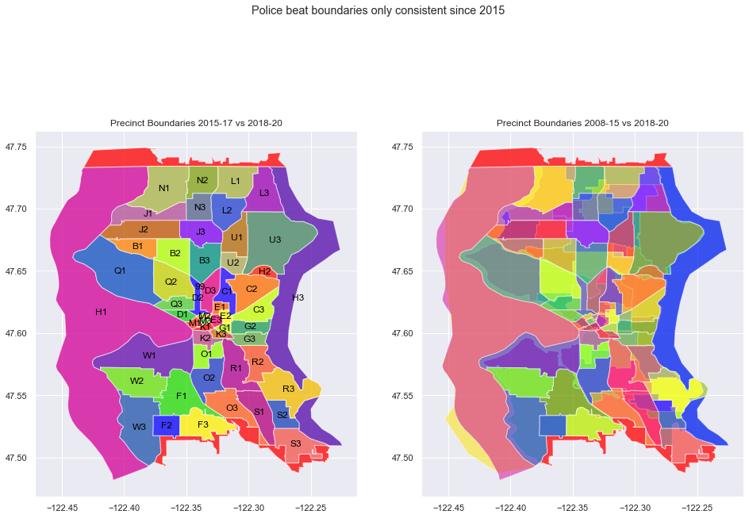

```python
# download police beat boundary data

# 2008-2015
spd_beats_08_15 = gpd.read_file('https://opendata.arcgis.com/datasets/ef08a89e6ec94c7a82515e47384f2808_0.geojson',
                      driver='GeoJSON')

# 2015-2017
spd_beats_15_17 = gpd.read_file('https://opendata.arcgis.com/datasets/45495a3ab3a141dcb3277dc91c52ec5f_1.geojson',
                      driver='GeoJSON')

# 2018- Present
spd_beats_18_20 = gpd.read_file('https://opendata.arcgis.com/datasets/36378b7acb8a464c8019b9618fecd0dd_2.geojson',
                      driver='GeoJSON')

# confirm precint areas and beats are consistent across time
plt.figure(figsize=(16, 12))

kwargs = {'title' : 'Precinct Boundaries 2015-17 vs 2018-20'}
ax = plt.subplot(1,2, 1, **kwargs)

kwargs = {'title' : 'Precinct Boundaries 2008-15 vs 2018-20'}
ax1 = plt.subplot(1,2,2,**kwargs)

spd_beats_15_17.plot(alpha=0.5, cmap='prism', ax = ax, figsize=(12,16));
spd_beats_08_15.plot(alpha=0.5, cmap='prism', ax = ax1, figsize=(12,16));

spd_beats_18_20.plot(alpha=0.5, cmap='prism', ax = ax);
spd_beats_18_20.plot(alpha=0.5, cmap='prism', ax = ax1);

# label beats
spd_beats_18_20.apply(lambda x: ax.annotate(s=x.beat,
                                            xy=x.geometry.centroid.coords[0],
                                            ha='center',
                                            va='center',
                                            color='black',
                                            wrap=True,
                                           ),axis=1);

plt.subplots_adjust(top=0.935);
plt.suptitle(f"Police beat boundaries only consistent since 2015");
```

##### Get Use of Force incidents per police beat

```python
# count number of UoF incidents per police beat

# pull only data from 2015 to present to avoid changing boundary issues
start = np.datetime64('2015-01-01')
beat_counts = spd_uof.loc[(spd_uof['Occured_date_time'] >= start)
                               ].groupby(spd_uof['Beat']).agg(
    Incidents = ('Incident_Num', 'nunique'),
).reset_index()
beat_counts.columns = ['beat', 'count']

# determine how many incidents not assigned to a police beat
invalid_beats = ['SW', 'S', 'W', 'E', '99', '-', 'XX']
no_beat = beat_counts.loc[(beat_counts['beat'].isin(invalid_beats))]['count'].sum()
total_count = beat_counts['count'].sum()
print(f'{no_beat/total_count*100:.1f}% of Use of Force Incidents not assigned to a police beat')

# clean up invalid beat codes
beat_counts = beat_counts.loc[~(beat_counts['beat'].isin(invalid_beats))].reset_index(drop=True)
beat_counts.head(3)
```

```
6.2% of Use of Force Incidents not assigned to a police beat
```

|  | beat | count |
| --- | --- | --- |
| 0 | B1 | 151 |
| 1 | B2 | 124 |
| 2 | B3 | 102 |

##### Get crime incidents from 1-1-2015 to 5-31-2020

```python
# from Seattle data portal:
# https://data.seattle.gov/Public-Safety/SPD-Crime-Data-2008-Present/tazs-3rd5
seattle_crime = pd.read_csv('data/SPD_Crime_Data__2015-Present_slim.csv')
seattle_crime["Offense Start DateTime"] = pd.to_datetime(seattle_crime["Offense Start DateTime"])
seattle_crime.head(3)
```

|  | Offense ID | Offense Start DateTime | Group A B | Crime Against Category | Precinct | Beat |
| --- | --- | --- | --- | --- | --- | --- |
| 0 | 12605873663 | 2020-02-05 10:10:00 | A | SOCIETY | W | Q1 |
| 1 | 12605598696 | 2020-02-03 08:00:00 | A | PROPERTY | N | J3 |
| 2 | 12605567653 | 2020-02-02 20:30:00 | A | PROPERTY | N | U3 |

##### Get crime counts for each police beat

```python
# get total crime incidents by type for each beat
crimes_by_beat = seattle_crime.groupby(['Beat','Crime Against Category']).agg(
    count = ('Offense ID', 'count')
).unstack(level=[1], fill_value = 0)

clean_cols = [x[1] for x in crimes_by_beat.columns]
crimes_by_beat.columns = clean_cols
# crimes_by_beat.loc[:, 'total_crimes'] = crimes_by_beat[clean_cols].sum(axis=1)
# crimes_by_beat.loc[:, 'pct_person'] = crimes_by_beat['A_PERSON'] / crimes_by_beat['total_crimes']
# crimes_by_beat.loc[:, 'total_crimes']
crimes_by_beat = crimes_by_beat.drop(columns=['NOT_A_CRIME']).reset_index()
crimes_by_beat.head(3)
```

|  | Beat | PERSON | PROPERTY | SOCIETY |
| --- | --- | --- | --- | --- |
| 0 | 99 | 22 | 38 | 8 |
| 1 | B1 | 1306 | 7238 | 852 |
| 2 | B2 | 890 | 8565 | 702 |

##### Merge crime and use of force data

```python
spd_beats_uof =  pd.merge(spd_beats_18_20,
                             beat_counts,
                             how = 'left',
                             on = 'beat',
                             )
spd_beats_uof = spd_beats_uof.dropna(subset=['count'])

spd_beats_uof_crime = pd.merge(spd_beats_uof,
                             crimes_by_beat,
                             how = 'left',
                             left_on = 'beat',
                             right_on = 'Beat',
                             )
drop = ['OBJECTID', 'sector', 'shape_Length', 'shape_Area', 'Beat']
renamer = {'count' : 'uof_incidents', 'first_precinct' : 'precinct'}
spd_beats_uof_crime = spd_beats_uof_crime.drop(columns=drop)
spd_beats_uof_crime = spd_beats_uof_crime.rename(columns=renamer)

spd_beats_uof_crime.head(3)
```

|  | beat | precinct | geometry | uof_incidents | PERSON | PROPERTY | SOCIETY |
| --- | --- | --- | --- | --- | --- | --- | --- |
| 0 | B1 | N | POLYGON ((-122.40539 47.67582, -122.40537 47.6... | 151.0 | 1306 | 7238 | 852 |
| 1 | B2 | N | POLYGON ((-122.36620 47.67598, -122.36654 47.6... | 124.0 | 890 | 8565 | 702 |
| 2 | B3 | N | POLYGON ((-122.33800 47.66869, -122.33847 47.6... | 102.0 | 824 | 7873 | 574 |

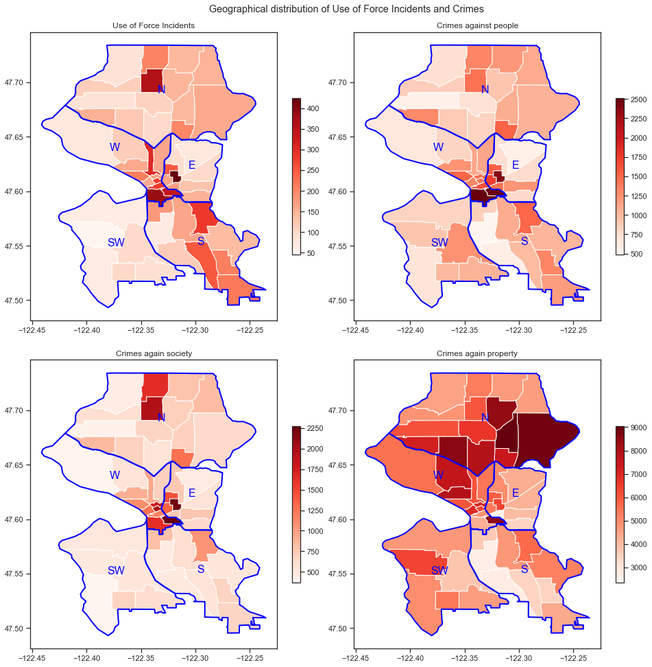

```python
# get precinct boundaries
precincts = spd_beats_uof_crime.groupby(['precinct']).agg(
    geometry = ('geometry', lambda x: x.unary_union)
).reset_index()

precincts_gdf = gpd.GeoDataFrame(precincts)
precincts_gdf.crs = 'epsg:4326'

# compare crime rates and Use of Force rates
plt.figure(figsize=(16, 24))
ax1 = ax2 = ax3 = ax4 = plt.subplot()
ax_list = [[ax1, 'uof_incidents', 1, 'Use of Force Incidents'],
           [ax2, 'PERSON', 2, 'Crimes against people'],
           [ax3, 'SOCIETY', 3, 'Crimes again society'],
           [ax4, 'PROPERTY', 4, 'Crimes again property']]
for ax_ in ax_list:
    kwargs = {'title' : ax_[3]}
    ax_[0] = plt.subplot(2,2, ax_[2], **kwargs)
    spd_beats_uof_crime.plot(cmap='Reds',
                             column=ax_[1],
                             legend=True,
                             legend_kwds={'shrink': 0.5},
                             ax = ax_[0]);
    precincts_gdf.geometry.boundary.plot(color=None,edgecolor='blue',linewidth = 2,ax=ax_[0])
    precincts.apply(lambda x: ax_[0].annotate(s = x.precinct,
                                          xy = x.geometry.centroid.coords[0],
                                          ha = 'center',
                                          color = 'blue',
                                          fontsize = 16), axis=1);

plt.tight_layout()
plt.subplots_adjust(
                    left = 0.1,  # the left side of the subplots of the figure
                      right = 0.9,  # the right side of the subplots of the figure
                      bottom = 0.49,  # the bottom of the subplots of the figure
                      top = 1.03,     # the top of the subplots of the figure
                      wspace = 0.05,  # the amount of width reserved for space between subplots,
                    hspace = 0.05);             # expressed as a fraction of the average axis width

plt.suptitle(f"Geographical distribution of Use of Force Incidents and Crimes",
             fontdict = {'fontsize' : 18}, va = 'bottom', y = 1.035);
```

### How have Use of Force Incidents trended over time?

```python
# choosing period of March 2015 through Feb 2020, five years with consistent police boundaries
# and avoid COVID, BLM protests and incidents not yet being logged in the system
# because using a rolling average, going to a rolling average number of days before the time period

# How many days of smoothing to use, how far apart should peak labels be
SMOOTH = 56
SEPARATE = 56

# set start date and end date of the plot
roll_start = date(2015, 3, 1)
end = date(2020, 2, 28)

# grab days from before the start for the rolling average
delta = timedelta(days=SMOOTH-1)
start = roll_start - delta

# add a column for just the date of the use of force incident,
# aggregate by date over by range
spd_uof.loc[:,'date'] = spd_uof['Occured_date_time'].dt.date
incidents_by_day = spd_uof.loc[(spd_uof['date'] >= start)
                               & (spd_uof['date'] <= end)].groupby(
                                    spd_uof['date'], as_index= False).agg(
    dates = ('date', 'first'),
    uof_incidents = ('Subject_ID', 'nunique'),
)

# add a column for just the date of the crime,
# aggregate by date over by range and ignore property crimes
seattle_crime.loc[:,'date'] = seattle_crime['Offense Start DateTime'].dt.date
crimes_by_day = seattle_crime.loc[(seattle_crime['date'] >= start)
                                  & (seattle_crime['date'] <= end)
                                  & (seattle_crime['Crime Against Category'].isin(['SOCIETY', 'PERSON']))].groupby(
                                    seattle_crime['date'], as_index= False).agg(
    dates = ('date', 'first'),
    crimes = ('Offense ID', 'count'),
)

crime_uof_by_day = crimes_by_day.merge(incidents_by_day,
                                       on = 'dates',
                                       how = 'left').fillna(0).set_index('dates')
crime_uof_by_day.head(3)
```

| dates | crimes | uof_incidents |
| --- | --- | --- |
| 2015-01-05 | 35 | 1.0 |
| 2015-01-06 | 35 | 6.0 |
| 2015-01-07 | 48 | 4.0 |

```python
# take a SMOOTH day rolling average to smooth the data. SMOOTH should be a multiple of 7
# to negate any day of the week effects, smooth out spordic events
# to look at monthly/seasonal effects
crime_uof_by_day.loc[:, 'uof_rolling'] = crime_uof_by_day['uof_incidents'].rolling(SMOOTH).mean()
crime_uof_by_day.loc[:, 'crime_rolling'] = crime_uof_by_day['crimes'].rolling(SMOOTH).mean()

# pull the date back into a column, dropna, and add a column for easy to read date format
crime_uof_by_day = crime_uof_by_day.dropna().reset_index()
crime_uof_by_day.loc[:, 'date_str'] = crime_uof_by_day['dates'].apply(lambda x: pd.Timestamp(x).strftime('%b %d'))

crime_uof_by_day.head(3)
```

|  | dates | crimes | uof_incidents | uof_rolling | crime_rolling | date_str |
| --- | --- | --- | --- | --- | --- | --- |
| 0 | 2015-03-01 | 47 | 2.0 | 3.785714 | 45.910714 | Mar 01 |
| 1 | 2015-03-02 | 43 | 4.0 | 3.839286 | 46.053571 | Mar 02 |
| 2 | 2015-03-03 | 41 | 7.0 | 3.857143 | 46.160714 | Mar 03 |

```python
# I wanted to label the five highest peaks and lowest troughs in the data
NUM_LABELS = 10

# find dates when the data goes from increasing to decreasing
data = crime_uof_by_day['uof_rolling'].values
doublediff = np.diff(np.sign(np.diff(data)))
peak_locations = np.where(doublediff == -2)[0] + 1

# find dates when the data goes from decreasing to increasing
doublediff2 = np.diff(np.sign(np.diff(-1*data)))
trough_locations = np.where(doublediff2 == -2)[0] + 1

# for each peak location, annotate with the full date, peak height, and date string
peak_heights = []
for peak in peak_locations:
    date_str = str(crime_uof_by_day.loc[peak, 'date_str'])
    incidents = crime_uof_by_day.loc[peak, 'uof_rolling']
    date_ = crime_uof_by_day.loc[peak, 'dates']
    peak_heights.append([date_, incidents, date_str])

# for each trough location, annotate with the full date, peak height, and date string
trough_heights = []
for trough in trough_locations:
    date_str = str(crime_uof_by_day.loc[trough, 'date_str'])
    incidents = crime_uof_by_day.loc[trough, 'uof_rolling']
    date_ = crime_uof_by_day.loc[trough, 'dates']
    trough_heights.append([date_, incidents, date_str])
```

```python
# sort the peaks in descending order, troughs in ascending order
peak_heights = sorted(peak_heights, key=lambda x: x[1])[::-1]
trough_heights = sorted(trough_heights, key=lambda x: x[1])

# I also wanted unique peaks, so I wanted to block out three days
# on either side of each peak to show unique peaks in the data
blocked_dates = []
unique_peaks = []
date_range = timedelta(days=SEPARATE)
delta = timedelta(days=1)

for peak in peak_heights:
    date_ =  peak[0]
    if date_ in blocked_dates:
        continue
    unique_peaks.append(peak)
    start = date_ - date_range
    end = date_ + date_range
    while start <= end:
        blocked_dates.append(start)
        start += delta

# Repeat the same process for troughs
blocked_dates = []
unique_troughs = []

for trough in trough_heights:
    date_ =  trough[0]
    if date_ in blocked_dates:
        continue
    unique_troughs.append(trough)
    start = date_ - date_range
    end = date_ + date_range
    while start <= end:
        blocked_dates.append(start)
        start += delta

# turn the peaks into a dataframe for plotting
unique_peaks_df = pd.DataFrame(unique_peaks[:NUM_LABELS])
unique_peaks_df.columns = ['DateFormat', 'Avg_Daily_Incidents', 'Date_Str']

# turn the troughs into a dataframe for plotting
unique_troughs_df = pd.DataFrame(unique_troughs[:NUM_LABELS])
unique_troughs_df.columns = ['DateFormat', 'Avg_Daily_Incidents', 'Date_Str']
unique_troughs_df.head()
```

|  | DateFormat | Avg_Daily_Incidents | Date_Str |
| --- | --- | --- | --- |
| 0 | 2019-11-01 | 1.839286 | Nov 01 |
| 1 | 2019-07-22 | 1.910714 | Jul 22 |
| 2 | 2019-04-04 | 2.017857 | Apr 04 |
| 3 | 2016-12-18 | 2.232143 | Dec 18 |
| 4 | 2020-02-17 | 2.321429 | Feb 17 |

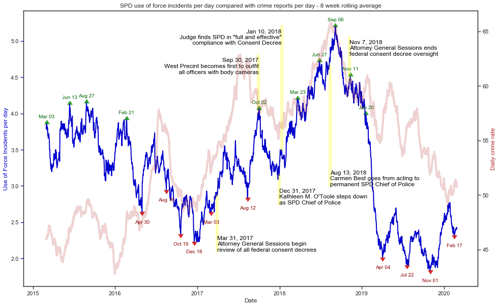

```python
# plot the full year of daily head counts
sns.set_style(style='ticks')

# set plot size, add the rolling average use of force data
fig, ax1 = plt.subplots(figsize=(16,10))
ax1 = sns.lineplot(x = crime_uof_by_day['dates'],
             y = crime_uof_by_day['uof_rolling'],
                   color= 'mediumblue',
                   linewidth=2,
                   alpha = 1,
                   zorder = 2
             );

# add markers for peaks
sns.scatterplot(data = unique_peaks_df,
                      x = 'DateFormat',
                      y = 'Avg_Daily_Incidents',
                      marker=mpl.markers.CARETUPBASE,
                      color='tab:green',
                      s=100,
                      label=f'{NUM_LABELS} Peaks',
                      legend=False,
                      ax=ax1,
                      zorder = 2
                     )

# add markers for troughs
sns.scatterplot(data = unique_troughs_df,
                      x = 'DateFormat',
                      y = 'Avg_Daily_Incidents',
                      marker=mpl.markers.CARETDOWNBASE,
                      color='tab:red',
                      s=100,
                      label=f'{NUM_LABELS} troughs',
                      legend=False,
                      ax=ax1,
                      zorder = 2
                     )

# add peak and trough annotations
for t, p in zip(unique_troughs[:NUM_LABELS], unique_peaks[:NUM_LABELS]):
    ax1.text(p[0], p[1]+.08, p[2], horizontalalignment='center',
             fontsize = 'small',
             color='darkgreen', zorder = 2
            )
    ax1.text(t[0], t[1]-.16, t[2], horizontalalignment='center',
             fontsize = 'small',
             color='darkred', zorder = 2
            )

# context
date_ = date(2018, 1, 10)
text = f'Jan 10, 2018\nJudge finds SPD in "full and effective"\n compliance with Consent Decree'
ax1.text(date_, 4.95, text, horizontalalignment='right', color='black', zorder = 2);
ax1.plot([date_, date_], [3.5, 5.2], color='yellow', linestyle='solid', linewidth=6, alpha=.3, zorder = 2);

text = f'Sep 30, 2017\nWest Precint becomes first to outfit\n all officers with body cameras'
date_ = date(2017, 9, 30)
ax1.text(date_, 4.55, text, horizontalalignment='right', color='black', zorder = 1);
ax1.plot([date_, date_], [4.05, 4.8], color='yellow', linestyle='solid', linewidth=6, alpha=.3, zorder = 1);

text = f'Nov 7, 2018\nAttorney General Sessions ends\nfederal consent decree oversight'
date_ = date(2018, 11, 7)
ax1.text(date_, 4.8, text, horizontalalignment='left', color='black', zorder = 2);
ax1.plot([date_, date_], [4.45, 5.05], color='yellow', linestyle='solid', linewidth=6, alpha=.3, zorder = 2);

text = f'Mar 31, 2017\nAttorney General Sessions begin\nreview of all federal consent decrees'
date_ = date(2017, 3, 31)
ax1.text(date_, 2.1, text, horizontalalignment='left', color='black', zorder = 2);
ax1.plot([date_, date_], [2.87, 2.1], color='yellow', linestyle='solid', linewidth=6, alpha=.3, zorder = 2);

text = f"Dec 31, 2017\nKathleen M. O'Toole steps down\nas SPD Chief of Police"
date_ = date(2017, 12, 31)
ax1.text(date_, 2.75, text, horizontalalignment='left', color='black', zorder = 2);
ax1.plot([date_, date_], [3.15, 2.75], color='yellow', linestyle='solid', linewidth=6, alpha=.3, zorder = 2);

text = f"Aug 13, 2018\nCarmen Best goes from acting to\npermanent SPD Chief of Police"
date_ = date(2018, 8, 13)
ax1.text(date_, 3, text, horizontalalignment='left', color='black', zorder = 2);
ax1.plot([date_, date_], [4.65, 3], color='yellow', linestyle='solid', linewidth=6, alpha=.3, zorder = 2);

# add title and axis labels
ax1.set_title('SPD use of force incidents per day compared with crime reports per day - 8 week rolling average')
ax1.set_xlabel('Date');
ax1.set_ylabel('Use of Force Incidents per day', fontsize=12, color= 'mediumblue')
ax1.tick_params(axis='y', color= 'mediumblue')


# add a second y-axis and the daily crime rate for context
ax2 = ax1.twinx()
ax2 = sns.lineplot(x = crime_uof_by_day['dates'],
             y = crime_uof_by_day['crime_rolling'],
                   color = 'firebrick',
                   linewidth=4,
                   alpha = .2,
                   zorder = 2
             );
ax2.set_ylabel('Daily crime rate', fontsize=12, color = 'firebrick');
```

### Milestone 2: Generate and evaluate a working model (linear, or time series)

```python
# helper functions

# plot ACF and PACF from Seth
def plot_acf_pacf(x, lags = 40):
    x = x[x.notna()] # remove NAs
    fig, axes = plt.subplots(1, 2, figsize = (15, 5))
    fig = splt.plot_acf(x, lags = lags, ax = axes[0])
    fig = splt.plot_pacf(x, lags = lags, ax = axes[1]);
    return None

# plot time series and residuals from Seth
def plot_ts_resid(x):
    x = x[x.notna()] # remove NAs
    fig, axes = plt.subplots(1, 2, figsize = (15, 5))
    fig = sns.lineplot(x.index, x, ax = axes[0])
    fig = sns.distplot(x, ax = axes[1]);
    return None

# Dicky-Fuller test from Seth
# tests null hypothesis that time series is non-stationary
def DF_Test(ts):
    ts = ts[ts.notna()]
    stationary = adfuller(ts)
    print('D-F statistic = ' + str(stationary[0]))
    print('p-value = ' + str(stationary[1]))
    print('number of lags used = ' + str(stationary[2]))
    print('Critical value at 5% confidence = ' + str(stationary[4]['5%']))
    print('Critical value at 10% confidence = ' + str(stationary[4]['10%']))
    return None

# STL decomposion from Seth
def decomp_ts(ts, period, model = 'additive'):
    res = sts.seasonal_decompose(ts, model = model, period = period)
    return(pd.DataFrame({'ts': ts, 'trend': res.trend, 'seasonal': res.seasonal, 'resid': res.resid},
                        index = ts.index))
```

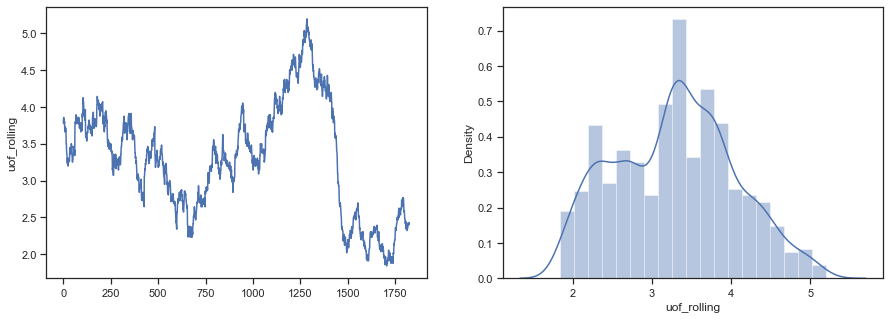

```python
# Determine if Use of Force is stationary
plot_ts_resid(crime_uof_by_day['uof_rolling']);
```

```python
# Conduct a Dicky-Fuller test
DF_Test(crime_uof_by_day['uof_rolling'])
```

```
D-F statistic = -1.4630886020398057
p-value = 0.5516855065914573
number of lags used = 0
Critical value at 5% confidence = -2.863125003847544
Critical value at 10% confidence = -2.56761380228936
```

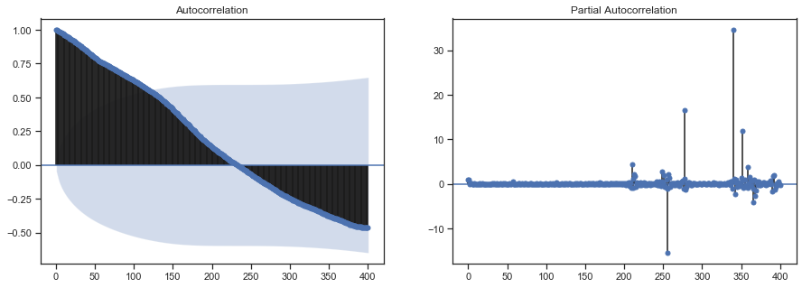

```python
# evaluate correlations of lags in the data
plot_acf_pacf(crime_uof_by_day['uof_rolling'], lags = 400)
```

### 3. Perform STL decomposition of the time series.

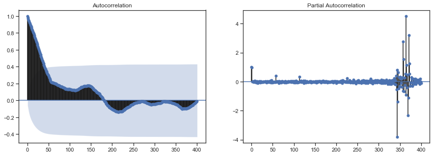

```python
# try decomposing with an annual period
PERIOD = 365
decomp = decomp_ts(crime_uof_by_day['uof_rolling'], period = PERIOD, model = 'additive')
decomp = decomp.bfill().ffill()
plot_acf_pacf(decomp.iloc[PERIOD:-PERIOD, 3], lags = 400)
```

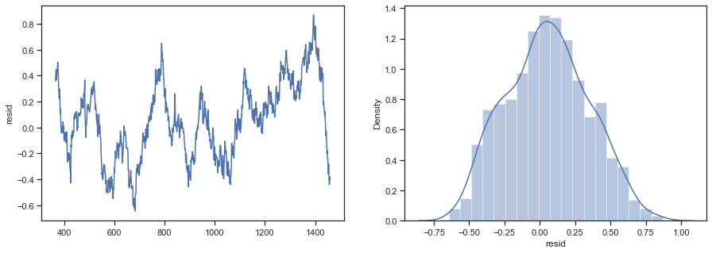

```python
plot_ts_resid(decomp.iloc[PERIOD:-PERIOD, 3]);
```

```python
# Conduct a Dicky-Fuller test
DF_Test(decomp.iloc[PERIOD:-PERIOD, 3])
```

```
D-F statistic = -2.682026740388394
p-value = 0.07720040078326569
number of lags used = 0
Critical value at 5% confidence = -2.8641831050780513
Critical value at 10% confidence = -2.568177274243656
```

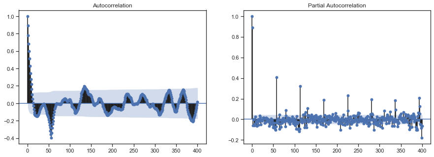

```python
# try decomposing with the smoothing period
PERIOD = 57
decomp = decomp_ts(crime_uof_by_day['uof_rolling'], period = PERIOD, model = 'additive')
decomp = decomp.bfill().ffill()
plot_acf_pacf(decomp.iloc[PERIOD:-PERIOD, 3], lags = 400)
```

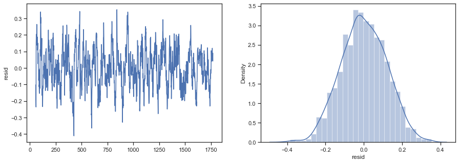

```python
plot_ts_resid(decomp.iloc[PERIOD:-PERIOD, 3]);
```

```python
# Conduct a Dicky-Fuller test
DF_Test(decomp.iloc[PERIOD:-PERIOD, 3])
```

```
D-F statistic = -10.09099430087148
p-value = 1.1223087442875492e-17
number of lags used = 10
Critical value at 5% confidence = -2.8632406484200064
Critical value at 10% confidence = -2.5676753800009053
```

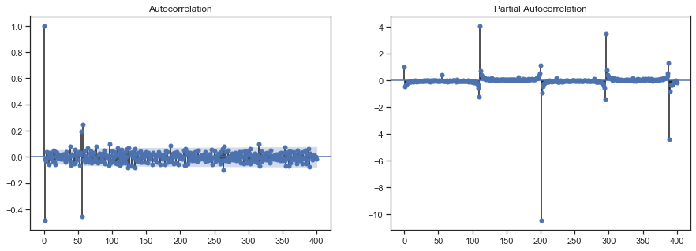

```python
# try decomposing with the previous day period
PERIOD = 2
decomp = decomp_ts(crime_uof_by_day['uof_rolling'], period = PERIOD, model = 'additive')
decomp = decomp.bfill().ffill()
plot_acf_pacf(decomp.iloc[PERIOD:-PERIOD, 3], lags = 400)
```

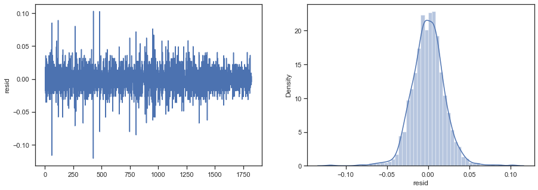

```python
plot_ts_resid(decomp.iloc[PERIOD:-PERIOD, 3]);
```

```python
# Conduct a Dicky-Fuller test
DF_Test(decomp.iloc[PERIOD:-PERIOD, 3])
```

```
D-F statistic = -15.097257554278237
p-value = 8.034475615740939e-28
number of lags used = 25
Critical value at 5% confidence = -2.863150617970021
Critical value at 10% confidence = -2.5676274409973163
```

### Use the auto_arima function from the pmdarima package to find a best model fit

```python
crime_uof_by_day['datetime'] = crime_uof_by_day['dates'].copy()
crime_uof_by_day['datetime'] = crime_uof_by_day['datetime'].apply(np.datetime64)
crime_uof_by_day.head()
```

|  | dates | crimes | uof_incidents | uof_rolling | crime_rolling | date_str | datetime |
| --- | --- | --- | --- | --- | --- | --- | --- |
| 0 | 2015-03-01 | 47 | 2.0 | 3.785714 | 45.910714 | Mar 01 | 2015-03-01 |
| 1 | 2015-03-02 | 43 | 4.0 | 3.839286 | 46.053571 | Mar 02 | 2015-03-02 |
| 2 | 2015-03-03 | 41 | 7.0 | 3.857143 | 46.160714 | Mar 03 | 2015-03-03 |
| 3 | 2015-03-04 | 40 | 1.0 | 3.803571 | 46.017857 | Mar 04 | 2015-03-04 |
| 4 | 2015-03-05 | 41 | 4.0 | 3.821429 | 46.089286 | Mar 05 | 2015-03-05 |

```python
validation_cut_off = np.datetime64('2019-01-01')
X_train = crime_uof_by_day.loc[crime_uof_by_day['datetime'] < validation_cut_off, 'uof_rolling'].copy()
X_valid = crime_uof_by_day.loc[crime_uof_by_day['datetime'] >= validation_cut_off, 'uof_rolling'].copy()

best_fit = auto_arima(X_train,
                      max_p = 3, max_d = 1, max_q = 3,
                      m = 7, max_P = 1, max_D = 1, max_Q = 1,
                      information_criterion = 'bic',
                      trace = True, error_action = 'ignore', suppress_warnings = True)

print(best_fit.summary())
```

```
Fit ARIMA: order=(2, 1, 2) seasonal_order=(1, 0, 1, 7); AIC=-3919.129, BIC=-3877.170, Fit time=2.769 seconds
Fit ARIMA: order=(0, 1, 0) seasonal_order=(0, 0, 0, 7); AIC=-3917.406, BIC=-3906.916, Fit time=0.249 seconds
Fit ARIMA: order=(1, 1, 0) seasonal_order=(1, 0, 0, 7); AIC=-3921.773, BIC=-3900.793, Fit time=0.427 seconds
Fit ARIMA: order=(0, 1, 1) seasonal_order=(0, 0, 1, 7); AIC=-3921.397, BIC=-3900.417, Fit time=0.405 seconds
Fit ARIMA: order=(0, 1, 0) seasonal_order=(1, 0, 0, 7); AIC=-3923.764, BIC=-3908.029, Fit time=0.173 seconds
Fit ARIMA: order=(0, 1, 0) seasonal_order=(1, 0, 1, 7); AIC=-3922.358, BIC=-3901.378, Fit time=0.426 seconds
Fit ARIMA: order=(0, 1, 1) seasonal_order=(1, 0, 0, 7); AIC=-3921.773, BIC=-3900.794, Fit time=0.687 seconds
Fit ARIMA: order=(1, 1, 1) seasonal_order=(1, 0, 0, 7); AIC=-3919.866, BIC=-3893.641, Fit time=0.957 seconds
Total fit time: 6.114 seconds
                                     SARIMAX Results
=========================================================================================
Dep. Variable:                                 y   No. Observations:                 1402
Model:             SARIMAX(0, 1, 0)x(1, 0, 0, 7)   Log Likelihood                1964.882
Date:                           Tue, 27 Apr 2021   AIC                          -3923.764
Time:                                   15:10:44   BIC                          -3908.029
Sample:                                        0   HQIC                         -3917.882
                                          - 1402
Covariance Type:                             opg
==============================================================================
                 coef    std err          z      P>|z|      [0.025      0.975]
------------------------------------------------------------------------------
intercept      0.0004      0.002      0.252      0.801      -0.003       0.004
ar.S.L7       -0.0774      0.030     -2.586      0.010      -0.136      -0.019
sigma2         0.0035   7.14e-05     49.633      0.000       0.003       0.004
===================================================================================
Ljung-Box (L1) (Q):                   0.01   Jarque-Bera (JB):              1514.91
Prob(Q):                              0.92   Prob(JB):                         0.00
Heteroskedasticity (H):               0.82   Skew:                             0.17
Prob(H) (two-sided):                  0.03   Kurtosis:                         8.08
===================================================================================

Warnings:
[1] Covariance matrix calculated using the outer product of gradients (complex-step).
```

### Forecast use of force for 2019-20

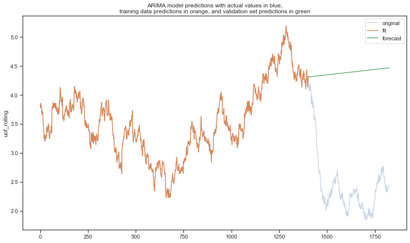

```python
# set up the index range for the data
start_idx = 1
train_idx = X_train.reset_index().index[start_idx:]
n_periods = len(X_valid)

# set up the plot
fig, ax = plt.subplots(1, 1, figsize = (14,8))

# plot the lines
sns.lineplot(crime_uof_by_day.index, crime_uof_by_day['uof_rolling'], alpha = 0.3)
sns.lineplot(X_train.index[train_idx], best_fit.predict_in_sample(start = start_idx, end = train_idx.max()))
sns.lineplot(X_valid.index, best_fit.predict(n_periods = n_periods))

# add legend and title
plt.legend(['original', 'fit', 'forecast']);
ax.set_title(f'ARIMA model predictions with actual values in blue,\ntraining data predictions in orange, and validation set predictions in green');
```

### Obviously a model based only on differencing has no predictive power. So I will evaluate the residuals from the training data and see if they seem random

```python
# get the RMSE for validation set predicted values
mse = mean_squared_error(X_train[1:], best_fit.predict_in_sample(start = start_idx, end = train_idx.max()))
mean_pred = np.mean(best_fit.predict_in_sample(start = start_idx, end = train_idx.max()))
print(f'RMSE = {mse**0.5:.2f}\nMean predicted value = {mean_pred:.2f}')
```

```
RMSE = 0.06
Mean predicted value = 3.55
```

```python
# add all the predictions to the dataframe and compute residuals
fill_nan = np.empty(n_periods)
fill_nan[:] = np.nan

crime_uof_by_day['uof_pred'] = np.concatenate((np.array([np.nan]),
                                     best_fit.predict_in_sample(start = start_idx, end = train_idx.max()),
                                               fill_nan
#                                      best_fit.predict(n_periods = n_periods))
                                             ))
crime_uof_by_day['uof_resid'] = crime_uof_by_day['uof_rolling'] - crime_uof_by_day['uof_pred']
```

```python
crime_uof_by_day['uof_resid'].dropna()
```

```
1       0.053197
2       0.017483
3      -0.053946
4       0.017483
5      -0.053946
          ...
1397   -0.048450
1398   -0.070451
1399    0.057312
1400    0.115027
1401   -0.003166
Name: uof_resid, Length: 1401, dtype: float64
```

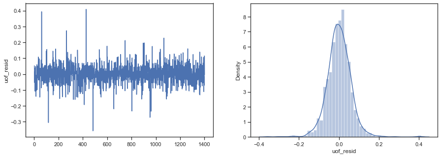

```python
# plot residuals and their distribution
plot_ts_resid(crime_uof_by_day['uof_resid'].dropna())
```

```python
# Conduct a Dicky-Fuller test
DF_Test(crime_uof_by_day['uof_resid'].dropna())
```

```
D-F statistic = -37.498858120876285
p-value = 0.0
number of lags used = 0
Critical value at 5% confidence = -2.8636066747959186
Critical value at 10% confidence = -2.5678702903061223
```